# RNA-seq之基因水平差异

### RNA-seq数据之差异基因分析

1. clusterProfiler http://www.360doc.com/content/19/0506/00/30846661_833639624.shtml
2. 注释基因包 http://bioconductor.org/packages/release/BiocViews.html
3. 参考文献 https://www.bioconductor.org/packages/devel/workflows/vignettes/RNAseq123/inst/doc/limmaWorkflow_CHN.html https://blog.csdn.net/weixin_45161743/article/details/103495069

### R Packages for DGE

limma edgeR DESeq clusterProfiler

### Bioconductor

http://www.bioconductor.org/

### 数据预处理

```r
library(edgeR)
options(stringsAsFactors = F)
library(airway)#气道平滑肌细胞RNA—seq
help(airway)#数据包中的help信息可以提供很多有用的信息，如参数意思
data("airway")
#获取基因counts矩阵
expr<-assay(airway)
?assay
expr[1:5,1:5]
#获取分组信息
group_list<-colData(airway)$dex
group_list
```

A matrix: 5 × 5 of type int

|  | SRR1039508 | SRR1039509 | SRR1039512 | SRR1039513 | SRR1039516 |
| --- | --- | --- | --- | --- | --- |
| ENSG00000000003 | 679 | 448 | 873 | 408 | 1138 |
| ENSG00000000005 | 0 | 0 | 0 | 0 | 0 |
| ENSG00000000419 | 467 | 515 | 621 | 365 | 587 |
| ENSG00000000457 | 260 | 211 | 263 | 164 | 245 |
| ENSG00000000460 | 60 | 55 | 40 | 35 | 78 |

1. untrt

2. trt

3. untrt

4. trt

5. untrt

6. trt

7. untrt

8. trt

**Levels**:**

1. 'trt'

2. 'untrt'

### 注释基因

```r
library(clusterProfiler)#Y叔开发的包（重点介绍）ID转换
library(org.Hs.eg.db)#人类基因组注释包
keytypes(org.Hs.eg.db)#查看支持ID的转换类型
#转换ID
geneid<-bitr(rownames(expr),fromType = "ENSEMBL",toType = "SYMBOL",
             OrgDb = "org.Hs.eg.db",drop=T)#去除空值
geneid
head(geneid)
```

1. 'ACCNUM'

2. 'ALIAS'

3. 'ENSEMBL'

4. 'ENSEMBLPROT'

5. 'ENSEMBLTRANS'

6. 'ENTREZID'

7. 'ENZYME'

8. 'EVIDENCE'

9. 'EVIDENCEALL'

10. 'GENENAME'

11. 'GO'

12. 'GOALL'

13. 'IPI'

14. 'MAP'

15. 'OMIM'

16. 'ONTOLOGY'

17. 'ONTOLOGYALL'

18. 'PATH'

19. 'PFAM'

20. 'PMID'

21. 'PROSITE'

22. 'REFSEQ'

23. 'SYMBOL'

24. 'UCSCKG'

25. 'UNIGENE'

26. 'UNIPROT'

```
Warning message in bitr(rownames(expr), fromType = "ENSEMBL", toType = "SYMBOL", :
"59.46% of input gene IDs are fail to map..."
```

A data.frame: 26268 × 2

|  | ENSEMBL <chr> | SYMBOL <chr> |
| --- | --- | --- |
| 1 | ENSG00000000003 | TSPAN6 |
| 2 | ENSG00000000005 | TNMD |
| 3 | ENSG00000000419 | DPM1 |
| 4 | ENSG00000000457 | SCYL3 |
| 5 | ENSG00000000460 | C1orf112 |
| 6 | ENSG00000000938 | FGR |
| 7 | ENSG00000000971 | CFH |
| 8 | ENSG00000001036 | FUCA2 |
| 9 | ENSG00000001084 | GCLC |
| 10 | ENSG00000001167 | NFYA |
| 11 | ENSG00000001460 | STPG1 |
| 12 | ENSG00000001461 | NIPAL3 |
| 13 | ENSG00000001497 | LAS1L |
| 14 | ENSG00000001561 | ENPP4 |
| 15 | ENSG00000001617 | SEMA3F |
| 16 | ENSG00000001626 | CFTR |
| 17 | ENSG00000001629 | ANKIB1 |
| 18 | ENSG00000001630 | CYP51A1 |
| 19 | ENSG00000001631 | KRIT1 |
| 20 | ENSG00000002016 | RAD52 |
| 22 | ENSG00000002330 | BAD |
| 23 | ENSG00000002549 | LAP3 |
| 24 | ENSG00000002586 | CD99 |
| 25 | ENSG00000002587 | HS3ST1 |
| 26 | ENSG00000002726 | AOC1 |
| 27 | ENSG00000002745 | WNT16 |
| 28 | ENSG00000002746 | HECW1 |
| 29 | ENSG00000002822 | MAD1L1 |
| 30 | ENSG00000002834 | LASP1 |
| 31 | ENSG00000002919 | SNX11 |
| ... | ... | ... |
| 63496 | ENSG00000273032 | DGCR5 |
| 63497 | ENSG00000273033 | LINC02035 |
| 63509 | ENSG00000273045 | C2orf15 |
| 63510 | ENSG00000273046 | HOXC5 |
| 63525 | ENSG00000273061 | CDC37L1-DT |
| 63543 | ENSG00000273079 | GRIN2B |
| 63549 | ENSG00000273085 | OR52E1 |
| 63550 | ENSG00000273086 | TAS2R9 |
| 63556 | ENSG00000273092 | TAS2R20 |
| 63575 | ENSG00000273111 | LYPD4 |
| 63589 | ENSG00000273125 | LINC01990 |
| 63593 | ENSG00000273129 | PACERR |
| 63600 | ENSG00000273136 | NBPF26 |
| 63631 | ENSG00000273167 | SPATA13 |
| 63637 | ENSG00000273173 | SNURF |
| 63677 | ENSG00000273213 | H3-2 |
| 63702 | ENSG00000273238 | TMEM271 |
| 63729 | ENSG00000273265 | CNNM3-DT |
| 63738 | ENSG00000273274 | ZBTB8B |
| 63758 | ENSG00000273294 | C1QTNF3-AMACR |
| 63761 | ENSG00000273297 | LOC105375519 |
| 63775 | ENSG00000273311 | DGCR11 |
| 63777 | ENSG00000273313 | RBAKDN |
| 63790 | ENSG00000273326 | TAS2R7 |
| 63808 | ENSG00000273344 | PAXIP1-AS1 |
| 63860 | ENSG00000273396 | LINC01396 |
| 63861 | ENSG00000273397 | NDUFA6 |
| 63873 | ENSG00000273409 | LINC02712 |
| 63895 | ENSG00000273431 | TAS2R50 |
| 63921 | ENSG00000273457 | TAS2R13 |

A data.frame: 6 × 2

|  | ENSEMBL <chr> | SYMBOL <chr> |
| --- | --- | --- |
| 1 | ENSG00000000003 | TSPAN6 |
| 2 | ENSG00000000005 | TNMD |
| 3 | ENSG00000000419 | DPM1 |
| 4 | ENSG00000000457 | SCYL3 |
| 5 | ENSG00000000460 | C1orf112 |
| 6 | ENSG00000000938 | FGR |

```r
#注释ID
expr<-expr[rownames(expr)%in%geneid[,1],]
dim(expr)
geneid<-geneid[match(rownames(expr),geneid[,1]),]
rownames(expr)<-geneid$SYMBOL
head(expr)
expr[1:5,1:5]
```

1. 25988

2. 8

A matrix: 6 × 8 of type int

|  | SRR1039508 | SRR1039509 | SRR1039512 | SRR1039513 | SRR1039516 | SRR1039517 | SRR1039520 | SRR1039521 |
| --- | --- | --- | --- | --- | --- | --- | --- | --- |
| TSPAN6 | 679 | 448 | 873 | 408 | 1138 | 1047 | 770 | 572 |
| TNMD | 0 | 0 | 0 | 0 | 0 | 0 | 0 | 0 |
| DPM1 | 467 | 515 | 621 | 365 | 587 | 799 | 417 | 508 |
| SCYL3 | 260 | 211 | 263 | 164 | 245 | 331 | 233 | 229 |
| C1orf112 | 60 | 55 | 40 | 35 | 78 | 63 | 76 | 60 |
| FGR | 0 | 0 | 2 | 0 | 1 | 0 | 0 | 0 |

A matrix: 5 × 5 of type int

|  | SRR1039508 | SRR1039509 | SRR1039512 | SRR1039513 | SRR1039516 |
| --- | --- | --- | --- | --- | --- |
| TSPAN6 | 679 | 448 | 873 | 408 | 1138 |
| TNMD | 0 | 0 | 0 | 0 | 0 |
| DPM1 | 467 | 515 | 621 | 365 | 587 |
| SCYL3 | 260 | 211 | 263 | 164 | 245 |
| C1orf112 | 60 | 55 | 40 | 35 | 78 |

```r
#去重（chong）
table(duplicated(rownames(expr)))#统计重复基因数目
dim(expr)
#对重复基因名取平均表达量
if(sum(duplicated(rownames(expr)))>0)#判断是否重复
  expr1<-avereps(expr,ID=rownames(expr))
dim(expr1)
```

```
FALSE  TRUE
24811  1177
```

1. 25988

2. 8

1. 24811

2. 8

```r
#过滤低表达基因
apply(expr1,2,fivenum)#查看样本表达基因
apply(expr1,2,function(x)sum(x>1))
#过滤方法1---自定义
expr2<-expr1[apply(expr1,1,function(x) sum(x>1)>1),]
dim(expr2)
save(group_list,expr2,file="expr.Rdata")
```

A matrix: 5 × 8 of type dbl

| SRR1039508 | SRR1039509 | SRR1039512 | SRR1039513 | SRR1039516 | SRR1039517 | SRR1039520 | SRR1039521 |
| --- | --- | --- | --- | --- | --- | --- | --- |
| 0 | 0 | 0 | 0 | 0 | 0 | 0 | 0 |
| 0 | 0 | 0 | 0 | 0 | 0 | 0 | 0 |
| 24 | 20 | 32 | 16 | 27 | 31 | 25 | 22 |
| 473 | 418 | 540 | 312 | 545 | 659 | 427 | 447 |
| 297906 | 255662 | 513766 | 273878 | 397791 | 401539 | 378834 | 372489 |

**SRR1039508**

15694

**SRR1039509**

15591

**SRR1039512**

16068

**SRR1039513**

15177

**SRR1039516**

15951

**SRR1039517**

16090

**SRR1039520**

15734

**SRR1039521**

15557

1. 16777

2. 8

```r
#过滤方法2
x<-edgeR::DGEList(counts=expr1)#构建DGEList
dim(x)
keep.exprs<-edgeR::filterByExpr(x,group=group_list)#判断基因是否低表达
x<-x[keep.exprs,,keep.lib.sizes=F]
dim(x)
head(keep.exprs)
dim(x)
```

1. 24811

2. 8

1. 13501

2. 8

**TSPAN6**

TRUE

**TNMD**

FALSE

**DPM1**

TRUE

**SCYL3**

TRUE

**C1orf112**

TRUE

**FGR**

FALSE

1. 13501

2. 8

1. 24811

2. 8

A matrix: 6 × 8 of type dbl

|  | SRR1039508 | SRR1039509 | SRR1039512 | SRR1039513 | SRR1039516 | SRR1039517 | SRR1039520 | SRR1039521 |
| --- | --- | --- | --- | --- | --- | --- | --- | --- |
| TSPAN6 | 5.141473 | 4.672112 | 5.2001552 | 4.839259 | 5.638631 | 5.172082 | 5.420317 | 4.841827 |
| TNMD | -3.367032 | -3.367032 | -3.3670321 | -3.367032 | -3.367032 | -3.367032 | -3.367032 | -3.367032 |
| DPM1 | 4.603281 | 4.872472 | 4.7103095 | 4.679162 | 4.686195 | 4.783291 | 4.538267 | 4.671255 |
| SCYL3 | 3.762943 | 3.592004 | 3.4780315 | 3.531635 | 3.433178 | 3.519089 | 3.703294 | 3.528445 |
| C1orf112 | 1.681397 | 1.684784 | 0.8293573 | 1.347256 | 1.809396 | 1.176655 | 2.109043 | 1.629866 |
| FGR | -3.367032 | -3.367032 | -2.4665716 | -3.367032 | -2.830181 | -3.367032 | -3.367032 | -3.367032 |

1. 24811

2. 8

1. 13501

2. 8

A matrix: 6 × 8 of type dbl

|  | SRR1039508 | SRR1039509 | SRR1039512 | SRR1039513 | SRR1039516 | SRR1039517 | SRR1039520 | SRR1039521 |
| --- | --- | --- | --- | --- | --- | --- | --- | --- |
| TSPAN6 | 5.142449 | 4.673067 | 5.2011922 | 4.840105 | 5.639665 | 5.173012 | 5.421656 | 4.842878 |
| DPM1 | 4.604257 | 4.873427 | 4.7113465 | 4.680008 | 4.687229 | 4.784222 | 4.539606 | 4.672305 |
| SCYL3 | 3.763919 | 3.592959 | 3.4790684 | 3.532482 | 3.434212 | 3.520020 | 3.704632 | 3.529495 |
| C1orf112 | 1.682374 | 1.685741 | 0.8303934 | 1.348108 | 1.810430 | 1.177589 | 2.110376 | 1.630916 |
| CFH | 7.398711 | 7.705985 | 8.0207753 | 8.217182 | 8.199507 | 8.566205 | 8.167782 | 8.643355 |
| FUCA2 | 6.217918 | 5.915106 | 6.1885216 | 5.948053 | 5.962550 | 5.630760 | 6.239856 | 5.795687 |

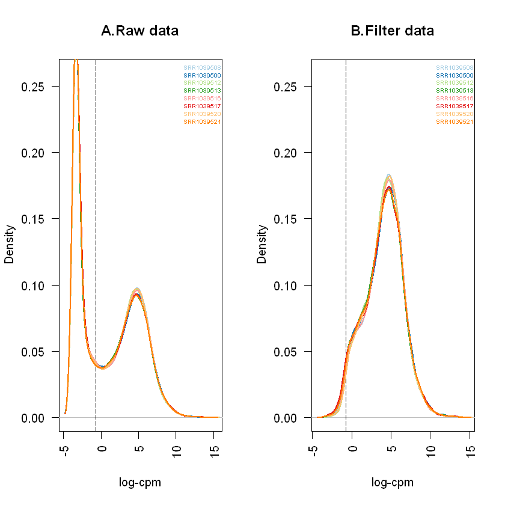

```r
#可视化过滤方法2中数据
library(RColorBrewer)
x<-edgeR::DGEList(counts=expr1,group=factor(group_list))
dim(x)
L<-mean(x$samples$lib.size)/10^6
M<-median(x$samples$lib.size)/10^6
lcpm<-cpm(x,log=T,prior.count = 2)#log2(CPM+2/L)
head(lcpm)
dim(x)
lcpm.cutoff<-log2(10/M+2/L)#过滤阈值
nsamples<-ncol(x)#提取样本数
col<-brewer.pal(nsamples,"Paired")#颜色
par(mfrow=c(1,2))
#过滤前图形
plot(density(lcpm[,1]),col=col[1],lwd=2,ylim=c(0,0.26),las=2,main="",
     xlab="")
abline(v=lcpm.cutoff,lty=5)#阈值线
for(i in 2:nsamples){
  den<-density(lcpm[,i])
  lines(den$x,den$y,col=col[i],lwd=2)
}
title(main="A.Raw data",xlab="log-cpm")
legend("topright",colnames(x),text.col=col,bty="n",cex=0.5)
#过滤后图形
keep.exprs<-edgeR::filterByExpr(x,group=group_list)
x<-x[keep.exprs,,keep.lib.sizes=F]#过滤
dim(x)
Lcpm<-cpm(x,log=T,prior.count = 2)
head(Lcpm)
plot(density(Lcpm[,1]),col=col[1],lwd=2,ylim=c(0,0.26),las=2,main="",
     xlab="")
abline(v=lcpm.cutoff,lty=5)#阈值线
for(i in 2:nsamples){
  den<-density(Lcpm[,i])
  lines(den$x,den$y,col=col[i],lwd=2)
}
title(main="B.Filter data",xlab="log-cpm")
legend("topright",colnames(x),text.col=col,bty="n",cex=0.5)
```

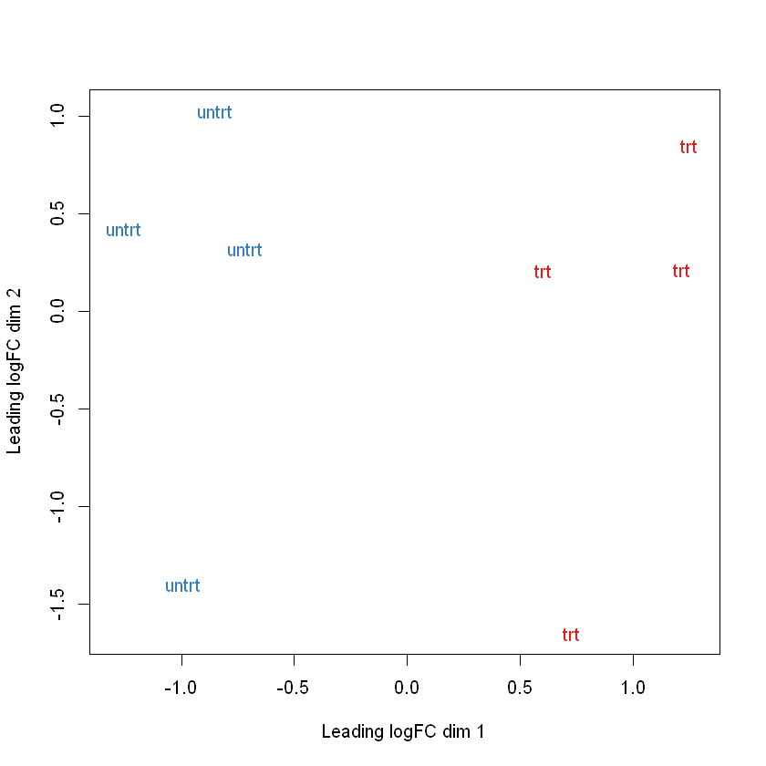

```r
#无监督聚类MDS图
par(mfrow=c(1,1))
lcpm<-cpm(x,log=T)
col.group<-group_list
levels(col.group)<-brewer.pal(nlevels(col.group),"Set1")

col.group<-as.character(col.group)
plotMDS(lcpm,col=col.group,labels=group_list)
```

### 差异性分析(Limma)

```r
library(limma)
options(stringsAsFactors = F)
load("expr.RData")#过滤方法1下的基因表达矩阵
data<-expr2
dim(data)
```

1. 16777

2. 8

```r
# 分组矩阵
group_list = factor(group_list)
design <- model.matrix(~0+group_list)
rownames(design) = colnames(data)
colnames(design) <- levels(group_list)
```

```r
# 差异比较矩阵
cont.matrix <- makeContrasts(contrasts = c('trt-untrt'),
                             levels = design)
```

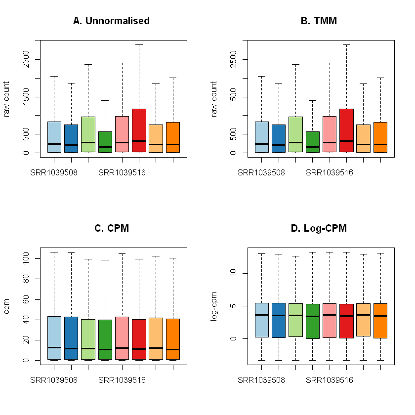

```r
#建模前归一化
#方法一：通过箱线图查看数据整齐与否后决定是否归一化
library(RColorBrewer)
dge <- DGEList(counts = data)
col <- brewer.pal(ncol(dge$counts), "Paired")
par(mfrow=c(2,2))
boxplot(dge$counts,outline=F, col=col)
title(main="A. Unnormalised ",ylab="raw count")
boxplot(calcNormFactors(dge, method = "TMM")$counts,outline=F,col=col)
title(main="B. TMM ",ylab="raw count")
boxplot(cpm(dge$counts),outline=F, col=col)
title(main="C. CPM ",ylab="cpm")
boxplot(cpm(dge$counts,log=TRUE),outline=F, col=col)
title(main="D. Log-CPM ",ylab="log-cpm")
```

### 结论

从上面的图形可看出log-cpm归一化效果最好,若直接用log-cpm化效果不佳,可先通过TMM标准化在进行log-cpm化.

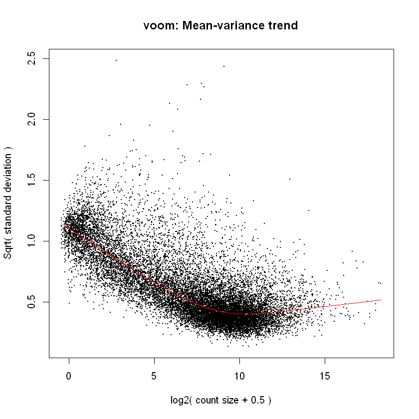

```r
#方法2：用limma包中的voom进行进行归一化
dge <- DGEList(counts = data)
dge <- calcNormFactors(dge)
v <- voom(dge, design, plot=T) #会自动计算log(cpm)值
```

voom图：显示一个均值与方差之间递减的趋势,生物差异高的实验通常会到更平坦的趋势,其方差在高表达处稳定；生物差异低的实验很可能会急剧下降的趋势.

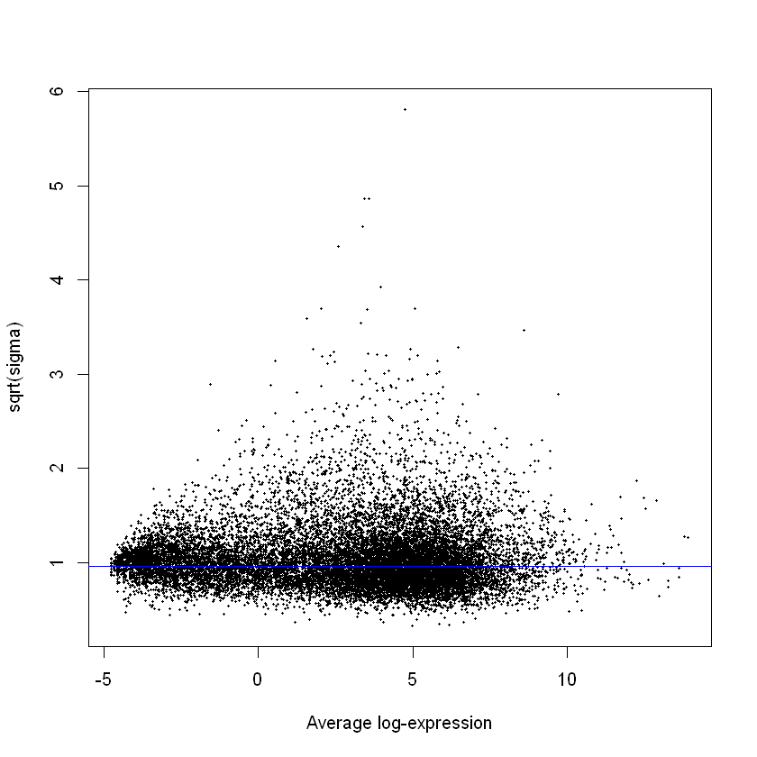

```r
#建模---使用的为voom归一化后的数据
#拟合线性模型
fit<-lmFit(v,design)
#针对给定的对比计算估计系数以及标准误差
fit2<-contrasts.fit(fit,cont.matrix)
#计算t,F,差异表达倍数的对数
fit2<-eBayes(fit2)
plotSA(fit2)
```

```r
#提取差异基因方法1
#用decideTests
#查看差异基因数目
summary(decideTests(fit2,lfc=1,p.value = 0.05))
#提取
allDEG<-topTable(fit2,coef="trt-untrt",n=Inf)
allDEG<-na.omit(allDEG)
dt<-decideTests(fit2)
summary(dt)
de.common<-which(dt[,1]!=0)
diff<-allDEG[de.common,]
head(dt)
dim(diff)
```

```
       trt-untrt
Down         317
NotSig     16117
Up           343
```

```
       trt-untrt
Down         811
NotSig     14965
Up          1001
```

A TestResults: 6 × 1 of type dbl

|  | trt-untrt |
| --- | --- |
| TSPAN6 | 0 |
| DPM1 | 0 |
| SCYL3 | 0 |
| C1orf112 | 0 |
| CFH | 0 |
| FUCA2 | 0 |

1. 1812

2. 6

基因集获取：http://bioinf.wehi.edu.au/software/MSigDB/

```r
##检查
#将基因按照校正p值从小到大排列输出所有结果
df <- topTreat(fit2, coef=1, n=Inf)
head(df)
#基因集检验
library(clusterProfiler)
library(org.Hs.eg.db)
load("human_c2_v5p2.rdata")
#使用voom归一化的数据
geneid<-bitr(rownames(v), fromType='SYMBOL', toType='ENTREZID',
             OrgDb='org.Hs.eg.db', drop = TRUE)
idx <- ids2indices(Hs.c2,id=geneid$ENTREZID) #匹配基因集
cam<- camera(v,idx,design,contrast=cont.matrix)
head(idx,3)
head(cam)
```

A data.frame: 6 × 6

|  | logFC <dbl> | AveExpr <dbl> | t <dbl> | P.Value <dbl> | adj.P.Val <dbl> | B <dbl> |
| --- | --- | --- | --- | --- | --- | --- |
| SPARCL1 | 4.574965 | 4.254079 | 18.78513 | 1.305430e-08 | 0.0001320285 | 9.324703 |
| PHC2 | 1.382352 | 6.926086 | 16.83671 | 3.459629e-08 | 0.0001320285 | 9.394810 |
| STOM | 1.442084 | 8.943205 | 16.73209 | 3.656354e-08 | 0.0001320285 | 9.177518 |
| PER1 | 3.187280 | 4.507597 | 16.72064 | 3.678642e-08 | 0.0001320285 | 9.038168 |
| MT2A | 2.201373 | 7.111247 | 16.59420 | 3.934805e-08 | 0.0001320285 | 9.260883 |
| DUSP1 | 2.950562 | 6.731630 | 16.17833 | 4.927101e-08 | 0.0001377700 | 9.059292 |

**$KEGG_GLYCOLYSIS_GLUCONEOGENESIS**

1. 120

2. 891

3. 903

4. 1067

5. 1150

6. 1321

7. 1720

8. 2144

9. 2332

10. 2701

11. 2937

12. 3113

13. 3131

14. 3195

15. 3395

16. 3429

17. 3440

18. 3443

19. 3452

20. 4119

21. 5507

22. 5593

23. 5720

24. 5919

25. 6321

26. 6367

27. 7033

28. 7142

29. 7291

30. 7921

31. 7968

32. 8157

33. 8378

34. 8521

35. 8812

36. 9708

37. 9759

38. 10075

39. 10077

40. 10375

41. 10568

42. 10895

43. 11006

44. 11060

45. 11162

46. 12605

47. 13104

48. 13406

49. 13482

50. 13740

51. 13793

52. 15019

53. 15925

**$KEGG_CITRATE_CYCLE_TCA_CYCLE**

1. 304

2. 750

3. 918

4. 1109

5. 1720

6. 1728

7. 2055

8. 2144

9. 2236

10. 2835

11. 4081

12. 4325

13. 4623

14. 5556

15. 5593

16. 6206

17. 6583

18. 7165

19. 7608

20. 7968

21. 9370

22. 10007

23. 10375

24. 11063

25. 11262

26. 12264

27. 13647

28. 14184

**$KEGG_PENTOSE_PHOSPHATE_PATHWAY**

1. 374

2. 581

3. 891

4. 1321

5. 2296

6. 2701

7. 3195

8. 5380

9. 6321

10. 7033

11. 7094

12. 7667

13. 7921

14. 8157

15. 8249

16. 8892

17. 9480

18. 9759

19. 10568

20. 10870

21. 11713

22. 13699

23. 15421

A data.frame: 6 × 4

|  | NGenes <dbl> | Direction <chr> | PValue <dbl> | FDR <dbl> |
| --- | --- | --- | --- | --- |
| BIOCARTA_ACTINY_PATHWAY | 19 | Up | 3.896315e-05 | 0.1839451 |
| REACTOME_SEMA4D_IN_SEMAPHORIN_SIGNALING | 28 | Up | 5.361421e-04 | 0.5368448 |
| CHEN_LVAD_SUPPORT_OF_FAILING_HEART_UP | 99 | Up | 6.463547e-04 | 0.5368448 |
| DAVIES_MULTIPLE_MYELOMA_VS_MGUS_DN | 21 | Up | 7.632493e-04 | 0.5368448 |
| STEGER_ADIPOGENESIS_UP | 15 | Up | 8.956429e-04 | 0.5368448 |
| JECHLINGER_EPITHELIAL_TO_MESENCHYMAL_TRANSITION_DN | 61 | Up | 9.174624e-04 | 0.5368448 |

```r
getwd()
```

'C:/Users/31207'

```r
#提取2 自定义阈值
allDEG <- topTable(fit2, coef = 'trt-untrt', n = Inf)
allDEG <- na.omit(allDEG)
padj = 0.05
foldChange= 1
diff_signif = allDEG[(allDEG$adj.P.Val < padj & abs(allDEG$logFC)>foldChange),]
diff_signif = diff_signif[order(diff_signif$logFC),]
save(diff_signif, file = 'limma_diff.Rdata')
dim(diff_signif)
head(diff_signif)
a<-diff_signif
```

1. 660

2. 6

A data.frame: 6 × 6

|  | logFC <dbl> | AveExpr <dbl> | t <dbl> | P.Value <dbl> | adj.P.Val <dbl> | B <dbl> |
| --- | --- | --- | --- | --- | --- | --- |
| LINC00906 | -4.387631 | -1.15315187 | -3.683866 | 4.918911e-03 | 0.0472920174 | -1.9708390 |
| MCHR1 | -4.207932 | -2.72930547 | -8.633729 | 1.088733e-05 | 0.0015639303 | 0.4953098 |
| LRRTM2 | -4.169559 | -0.02831165 | -8.294587 | 1.511796e-05 | 0.0018649561 | 2.1409081 |
| VCAM1 | -3.686535 | 3.65813483 | -10.691994 | 1.814316e-06 | 0.0006764174 | 5.4886506 |
| VASH2 | -3.627419 | -1.00508844 | -8.403856 | 1.358500e-05 | 0.0017917458 | 1.6860112 |
| SMTNL2 | -3.522934 | 0.41710895 | -3.695834 | 4.827700e-03 | 0.0469016124 | -1.7974586 |

### 数据可视化分析之火山图&热图&富集图

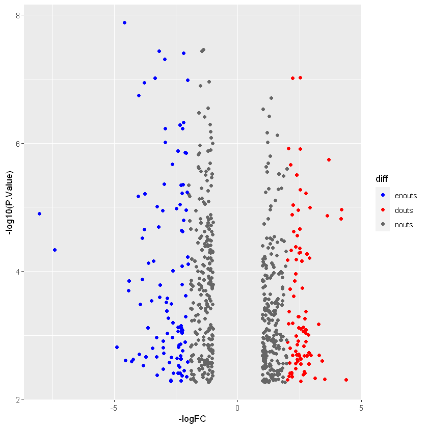

```r
#火山图
load(file="limma_diff.Rdata")
library(ggplot2)
diff_signif[which(diff_signif$P.Value<0.05&
              diff_signif$logFC>=2),"diff"]<-"up"
diff_signif[which(diff_signif$P.Value<0.05&
                 diff_signif$logFC<=-2),"diff"]<-"down"
diff_signif[!(diff_signif$diff %in% c("up","down")),"diff"]<-"no"
p1<-ggplot(diff_signif,aes(x=-logFC,y=-log10(P.Value)))+
  geom_point(aes(col=diff),size=1.5)+
  scale_color_manual(limits=c("up","down","no"),
 values=c("blue","red","gray40"),labels=c("enouts","douts","nouts"))
p1
```

### 基因表达量热图

A matrix: 6 × 8 of type dbl

|  | SRR1039508 | SRR1039509 | SRR1039512 | SRR1039513 | SRR1039516 | SRR1039517 | SRR1039520 | SRR1039521 |
| --- | --- | --- | --- | --- | --- | --- | --- | --- |
| TSPAN6 | 679 | 448 | 873 | 408 | 1138 | 1047 | 770 | 572 |
| DPM1 | 467 | 515 | 621 | 365 | 587 | 799 | 417 | 508 |
| SCYL3 | 260 | 211 | 263 | 164 | 245 | 331 | 233 | 229 |
| C1orf112 | 60 | 55 | 40 | 35 | 78 | 63 | 76 | 60 |
| CFH | 3251 | 3679 | 6177 | 4252 | 6721 | 11027 | 5176 | 7995 |
| FUCA2 | 1433 | 1062 | 1733 | 881 | 1424 | 1439 | 1359 | 1109 |

1. 'FENDRR'

2. 'LOC644656'

3. 'HAVCR1P1'

4. 'LOC93429'

5. 'MIR4453HG'

6. 'LOC105372482'

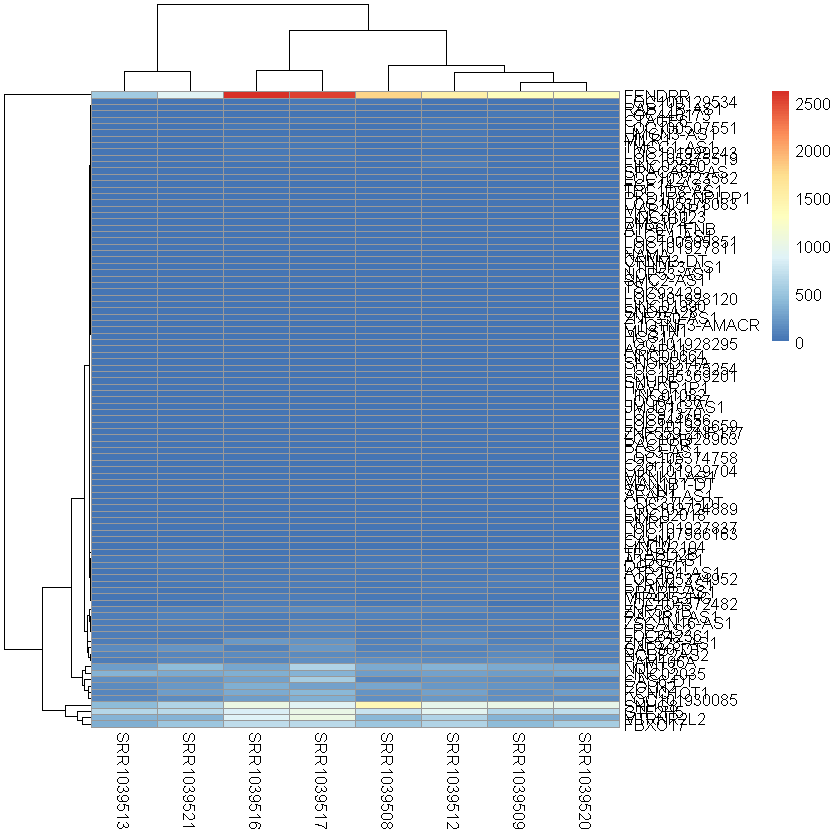

```r
#allsample_top100sd_count_heatmap
load("expr.Rdata")
library(pheatmap)
head(expr2)
cg<-names(tail(apply(expr2,1,sd),100))#取表达量标准差前100的行名
head(cg)
pheatmap(expr2[cg,])
```

```
group_list
  trt untrt
    4     4
```

A matrix: 3 × 3 of type dbl

|  | SRR1039508 | SRR1039509 | SRR1039512 |
| --- | --- | --- | --- |
| FENDRR | 0.3229845 | -0.3497569 | -0.08615209 |
| LOC644656 | 1.7677670 | -1.0606602 | 1.29636243 |
| HAVCR1P1 | 1.1692679 | -0.7015608 | -0.70156076 |

1. 8

2. 1

1. 100

2. 8

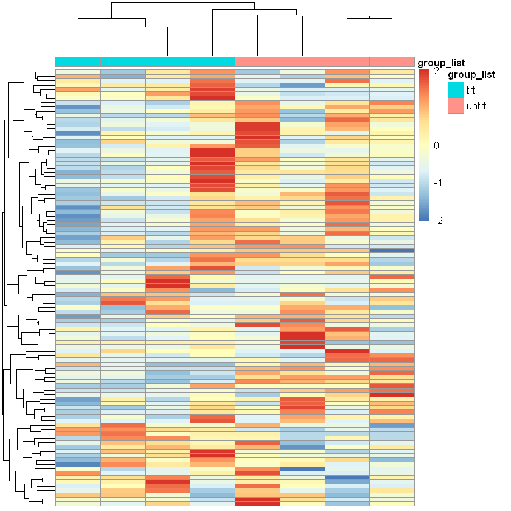

```r
#中心化、标准化allsample_top100sd_cutree1.pheatmap
table(group_list)
n<-t(scale(t(expr2[cg,])))
n[1:3,1:3]
n[n>2]=2
n[n<-2]=-2
ac<-data.frame(group_list)
#判断ac的行数是否等于n的列数
dim(ac)
dim(n)
rownames(ac)<-colnames(n)
pheatmap(n,show_rownames = F,show_colnames = F,annotation_col = ac)
```

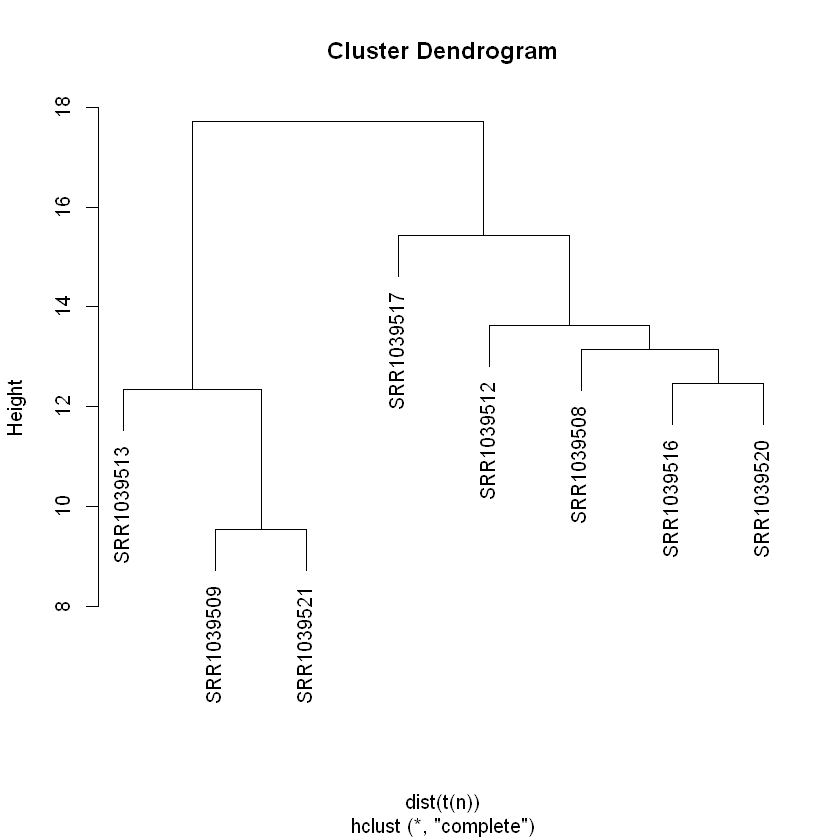

```r
#对表达量标准差前100的基因信息进行聚类
hc<-hclust(dist(t(n)))
plot(hc)
```

```
group_list1
1 2
5 3
```

```
           group_list
group_list1 trt untrt
          1   1     4
          2   3     0
```

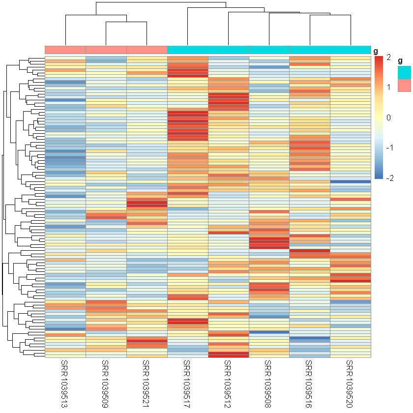

```r
#剪枝
c<-cutree(hc,2)
group_list1<-as.factor(c)#转换成因子
table(group_list1)#统计样本分组信息
table(group_list1,group_list)#得到混淆矩阵
ac1<-data.frame(g=group_list1)
rownames(ac1)<-colnames(n)
pheatmap(n,show_rownames = F,show_colnames = T,annotation_col = ac1)
```

### 富集分析

> 基因富集分析是分析基因表达信息的一种方法，富集是指将基因按照先验知识，也就是基因组注释信息进行分类。 人类有约30,000个基因，总碱基对的数量约32亿。目前约有3.2亿可能的碱基对变异情况，而每两个人之间的差异约为2千万个碱基对，也就是总碱基对的0.6%。换句话说，人与人之间的基因序列相似度高达99%以上。这些细微的差别，导致了我们长得不同，性格也不同。那么怎么更好的理解这些不同呢？可以按照功能、通路等性质将基因做划分，这也是基因富集分析的重要作用之一。

作者：师师 链接：https://www.zhihu.com/question/30778984/answer/91262467 来源：知乎 著作权归作者所有。商业转载请联系作者获得授权，非商业转载请注明出处。

```r
#富集图
library(clusterProfiler)#用来富集分析的包
```

```r
load("limma_diff.Rdata")
dim(diff_signif)
library(clusterProfiler)
library(org.Hs.eg.db)
library(topGO)
library(pathview)
c<-diff_signif
#将gene symbol 转换成行名
c$SYMBOL<-rownames(c)
head(c)
rownames(c)<-1:660
head(c)
class(c$SYMBOL)
```

1. 660

2. 6

A data.frame: 6 × 7

|  | logFC <dbl> | AveExpr <dbl> | t <dbl> | P.Value <dbl> | adj.P.Val <dbl> | B <dbl> | SYMBOL <chr> |
| --- | --- | --- | --- | --- | --- | --- | --- |
| LINC00906 | -4.387631 | -1.15315187 | -3.683866 | 4.918911e-03 | 0.0472920174 | -1.9708390 | LINC00906 |
| MCHR1 | -4.207932 | -2.72930547 | -8.633729 | 1.088733e-05 | 0.0015639303 | 0.4953098 | MCHR1 |
| LRRTM2 | -4.169559 | -0.02831165 | -8.294587 | 1.511796e-05 | 0.0018649561 | 2.1409081 | LRRTM2 |
| VCAM1 | -3.686535 | 3.65813483 | -10.691994 | 1.814316e-06 | 0.0006764174 | 5.4886506 | VCAM1 |
| VASH2 | -3.627419 | -1.00508844 | -8.403856 | 1.358500e-05 | 0.0017917458 | 1.6860112 | VASH2 |
| SMTNL2 | -3.522934 | 0.41710895 | -3.695834 | 4.827700e-03 | 0.0469016124 | -1.7974586 | SMTNL2 |

A data.frame: 6 × 7

|  | logFC <dbl> | AveExpr <dbl> | t <dbl> | P.Value <dbl> | adj.P.Val <dbl> | B <dbl> | SYMBOL <chr> |
| --- | --- | --- | --- | --- | --- | --- | --- |
| 1 | -4.387631 | -1.15315187 | -3.683866 | 4.918911e-03 | 0.0472920174 | -1.9708390 | LINC00906 |
| 2 | -4.207932 | -2.72930547 | -8.633729 | 1.088733e-05 | 0.0015639303 | 0.4953098 | MCHR1 |
| 3 | -4.169559 | -0.02831165 | -8.294587 | 1.511796e-05 | 0.0018649561 | 2.1409081 | LRRTM2 |
| 4 | -3.686535 | 3.65813483 | -10.691994 | 1.814316e-06 | 0.0006764174 | 5.4886506 | VCAM1 |
| 5 | -3.627419 | -1.00508844 | -8.403856 | 1.358500e-05 | 0.0017917458 | 1.6860112 | VASH2 |
| 6 | -3.522934 | 0.41710895 | -3.695834 | 4.827700e-03 | 0.0469016124 | -1.7974586 | SMTNL2 |

'character'

### bitr功能为ID转换

bitr(geneID, fromType, toType, OrgDb, drop = TRUE)； geneid ：基因ID输入 ； fromtype ： 输入ID型；toType：输出ID型；orgdb ：注释数据库）

```r
#数据转换
test1 = bitr(unique(c$SYMBOL), fromType="SYMBOL",
             toType= "ENTREZID", OrgDb="org.Hs.eg.db")
head(test1)
dim(test1)
```

A data.frame: 6 × 2

|  | SYMBOL <chr> | ENTREZID <chr> |
| --- | --- | --- |
| 1 | LINC00906 | 148145 |
| 2 | MCHR1 | 2847 |
| 3 | LRRTM2 | 26045 |
| 4 | VCAM1 | 7412 |
| 5 | VASH2 | 79805 |
| 6 | SMTNL2 | 342527 |

1. 660

2. 2

### GO dataset Analysis

> GO数据库总共有三大类，分别是生物学过程(Biological Process,BP)、细胞定位(Cellular Component,CC)、分子功能(Molecular Function,MF),各自描述了基因产物可能行使的分子功能，所处的细胞环境，以及参与的生物学过程.GO数据库中一个基本的概念是节点,比如"Cell"、"Fibroblast Growth Factor Receptor Binding"或者"Signal Transduction",同时有一个唯一的编号,如"GO:nnnnnnnn ".基于鉴定到的蛋白ID,采用mapping（比对)的方式从Uniprot数据库中 得到蛋白质的GO数据库注释信息,对蛋白质进行功能分类注释.

```r
#GO分析
#groupGO富集分析
ggo <- groupGO(gene = test1$ENTREZID, OrgDb = org.Hs.eg.db,
               ont = "CC",level = 3,readable = TRUE)
head(ggo)
```

[output not shown]

A data.frame: 6 × 5

|  | ID <fct> | Description <fct> | Count <int> | GeneRatio <fct> | geneID <chr> |
| --- | --- | --- | --- | --- | --- |
| GO:0005886 | GO:0005886 | plasma membrane | 229 | 229/660 | MCHR1/LRRTM2/VCAM1/GRIN2A/SLITRK6/AQP3/ASIC2/GPR68/AIF1L/TNF…… |
| GO:0005628 | GO:0005628 | prospore membrane | 0 | 0/660 |  |
| GO:0005789 | GO:0005789 | endoplasmic reticulum membrane | 30 | 30/660 | LCTL/HSD11B2/PLA2G4A/FLRT3/MEST/SCD/CH25H/CNIH3/HMOX1/TMEM119/GRAMD4/OSBPL3/ABCC6/ABCC6/TMCC2/OSBPL7/STIM2/PNPLA2/PREB/PCYT2/AGTRAP/YIF1B/GPAT3/CYP19A1/ATP10A/ATP2A2/EDA/ACSL1/MCTP1/SORT1 |
| GO:0019867 | GO:0019867 | outer membrane | 8 | 8/660 | FOXO3/STARD7/ACSL1/SEPTIN4/SEPTIN4/NAV3/MAOA/GUCY2D |
| GO:0031090 | GO:0031090 | organelle membrane | 89 | 89/660 | MCHR1/SLC7A14/NPC1L1/DOC2A/PLA2G4A/LFNG/RND2/CAMK2A/SLC6A9/R…… |
| GO:0034357 | GO:0034357 | photosynthetic membrane | 0 | 0/660 |  |

```r
#enrichGO富集分析
ego_ALL <- enrichGO(gene = test1$ENTREZID,
                    OrgDb = org.Hs.eg.db,
                    ont = "ALL",
                    pAdjustMethod = "BH",
                    pvalueCutoff = 1,
                    qvalueCutoff = 1,
                    readable = T)
head(ego_ALL,2)
```

A data.frame: 2 × 10

|  | ONTOLOGY <fct> | ID <chr> | Description <chr> | GeneRatio <chr> | BgRatio <chr> | pvalue <dbl> | p.adjust <dbl> | qvalue <dbl> | geneID <chr> | Count <int> |
| --- | --- | --- | --- | --- | --- | --- | --- | --- | --- | --- |
| GO:0007411 | BP | GO:0007411 | axon guidance | 29/558 | 276/18670 | 4.630024e-09 | 1.135587e-05 | 9.608369e-06 | EGR2/IGSF9/RPS6KA5/FLRT3/GFRA2/CXCL12/EPHB2/EPHB3/SEMA6D/EPHA5/VEGFA/SCN1B/SEMA3A/ROBO1/DOK6/SPTBN4/UNC5B/NRP2/APBB2/EPHB6/PIK3R1/GDNF/NOG/GDF7/NEXN/LAMA2/NR4A3/IRS2/PLXNA4 | 29 |
| GO:0097485 | BP | GO:0097485 | neuron projection guidance | 29/558 | 277/18670 | 5.029174e-09 | 1.135587e-05 | 9.608369e-06 | EGR2/IGSF9/RPS6KA5/FLRT3/GFRA2/CXCL12/EPHB2/EPHB3/SEMA6D/EPHA5/VEGFA/SCN1B/SEMA3A/ROBO1/DOK6/SPTBN4/UNC5B/NRP2/APBB2/EPHB6/PIK3R1/GDNF/NOG/GDF7/NEXN/LAMA2/NR4A3/IRS2/PLXNA4 | 29 |

```r
#setReadble函数进行转换
ego_MF <- enrichGO(gene = test1$ENTREZID,
                    OrgDb = org.Hs.eg.db,ont = "MF",
                   pAdjustMethod = "BH",pvalueCutoff = 1,
                   qvalueCutoff = 1,readable = FALSE)#ont可以选择"All","MF","BP","CC"
ego_MF1 <- setReadable(ego_MF, OrgDb = org.Hs.eg.db)
head(ego_MF,2)
```

A data.frame: 2 × 9

|  | ID <chr> | Description <chr> | GeneRatio <chr> | BgRatio <chr> | pvalue <dbl> | p.adjust <dbl> | qvalue <dbl> | geneID <chr> | Count <int> |
| --- | --- | --- | --- | --- | --- | --- | --- | --- | --- |
| GO:1901681 | GO:1901681 | sulfur compound binding | 22/553 | 250/17697 | 1.307357e-05 | 0.005550936 | 0.005108624 | 4856/10468/134526/7422/27010/8292/3673/8828/283/307/4329/875/59271/284654/3491/1311/7057/11096/9510/1301/83716/4316 | 22 |
| GO:0003779 | GO:0003779 | actin binding | 31/553 | 431/17697 | 1.550541e-05 | 0.005550936 | 0.005108624 | 79805/83543/286187/63876/81930/10391/11151/8507/5581/283431/65108/57731/2035/4771/9645/283/10810/25802/85464/3983/10611/23026/23500/171024/9788/10580/7225/91624/121512/84940/783 | 31 |

#### GO levels 分类统计图

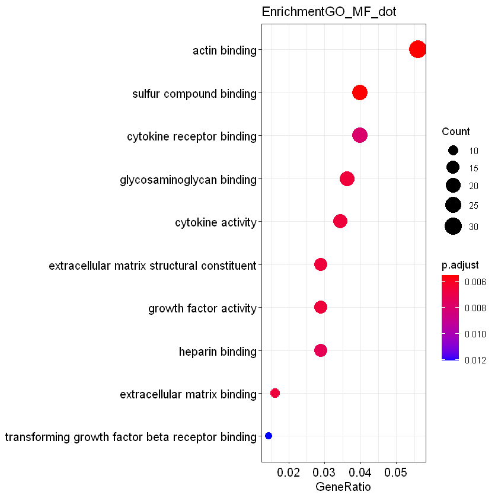

```r
#可视化--点图
dotplot(ego_MF,title="EnrichmentGO_MF_dot")#点图，按富集的数从大到小的
```

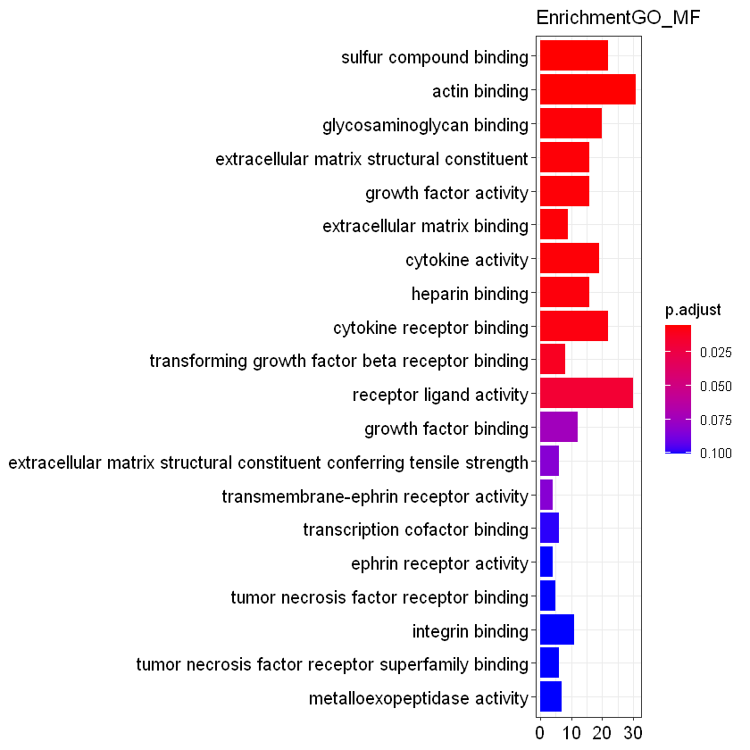

```r
#条状图，按p从小到大排，绘制前20个Term
barplot(ego_MF, showCategory=20,title="EnrichmentGO_MF")
```

[output not shown]

```
$dag
A graphNEL graph with directed edges
Number of Nodes = 22
Number of Edges = 24

$complete.dag
[1] "A graph with 22 nodes."
```

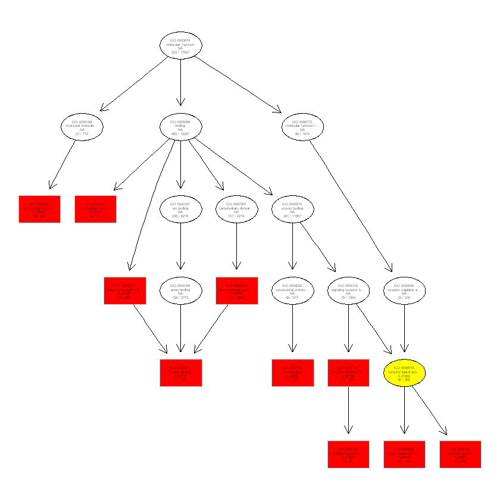

```r
plotGOgraph(ego_MF)#差异表达蛋白的topGO分子功能有向无环图
```

```r
#KEGG分析
#候选基因进行通路分析
k<-enrichKEGG(gene=test1$ENTREZID,organism = 'hsa',
              pvalueCutoff = 1)
head(k,2)
```

A data.frame: 2 × 9

|  | ID <chr> | Description <chr> | GeneRatio <chr> | BgRatio <chr> | pvalue <dbl> | p.adjust <dbl> | qvalue <dbl> | geneID <chr> | Count <int> |
| --- | --- | --- | --- | --- | --- | --- | --- | --- | --- |
| hsa04933 | hsa04933 | AGE-RAGE signaling pathway in diabetic complications | 13/277 | 100/8048 | 3.49086e-05 | 0.004549291 | 0.003733868 | 7412/8503/7042/1277/7422/3725/5581/1282/7048/5295/1286/1285/2308 | 13 |
| hsa04068 | hsa04068 | FoxO signaling pathway | 15/277 | 131/8048 | 4.06305e-05 | 0.004549291 | 0.003733868 | 8503/7042/1901/1030/8743/10769/1026/114907/2309/7048/4616/5295/51422/8660/2308 | 15 |

```r
#KEGG气泡图
dotplot(k,title="enrich keggdotplot")
```

[output not shown]

```r
#pathview通路可视化
library(pathview)
pathview(test1$ENTREZID,pathway.id = "04933",species = "hsa")
```

参考文献链接 https://zhuanlan.zhihu.com/p/35510434 https://www.jianshu.com/p/47b5ea646932 https://www.jianshu.com/p/1f820f43b775

### 细化富集分析处理过程

1. 读取差异基因表达矩阵
2. 设定阈值计算基因上调下调数量
3. ID转换
4. 得出差异基因(得到排序的geneList)

```r
#加载差异表达矩阵
load("limma_diff.Rdata")
head(diff_signif,3)
dim(diff_signif)
```

A data.frame: 3 × 6

|  | logFC <dbl> | AveExpr <dbl> | t <dbl> | P.Value <dbl> | adj.P.Val <dbl> | B <dbl> |
| --- | --- | --- | --- | --- | --- | --- |
| LINC00906 | -4.387631 | -1.15315187 | -3.683866 | 4.918911e-03 | 0.047292017 | -1.9708390 |
| MCHR1 | -4.207932 | -2.72930547 | -8.633729 | 1.088733e-05 | 0.001563930 | 0.4953098 |
| LRRTM2 | -4.169559 | -0.02831165 | -8.294587 | 1.511796e-05 | 0.001864956 | 2.1409081 |

1. 660

2. 6

```r
#设定阈值计算基因上调下调数目
a=diff_signif
logFC_t=1.5
a$g<-ifelse(a$P.Value>0.05,'stable',ifelse( a$logFC > logFC_t,'UP',
                      ifelse(a$logFC < -logFC_t,'DOWN','stable')))
table(a$g)
head(a)
```

```
  DOWN stable     UP
   160    326    174
```

A data.frame: 6 × 7

|  | logFC <dbl> | AveExpr <dbl> | t <dbl> | P.Value <dbl> | adj.P.Val <dbl> | B <dbl> | g <chr> |
| --- | --- | --- | --- | --- | --- | --- | --- |
| LINC00906 | -4.387631 | -1.15315187 | -3.683866 | 4.918911e-03 | 0.0472920174 | -1.9708390 | DOWN |
| MCHR1 | -4.207932 | -2.72930547 | -8.633729 | 1.088733e-05 | 0.0015639303 | 0.4953098 | DOWN |
| LRRTM2 | -4.169559 | -0.02831165 | -8.294587 | 1.511796e-05 | 0.0018649561 | 2.1409081 | DOWN |
| VCAM1 | -3.686535 | 3.65813483 | -10.691994 | 1.814316e-06 | 0.0006764174 | 5.4886506 | DOWN |
| VASH2 | -3.627419 | -1.00508844 | -8.403856 | 1.358500e-05 | 0.0017917458 | 1.6860112 | DOWN |
| SMTNL2 | -3.522934 | 0.41710895 | -3.695834 | 4.827700e-03 | 0.0469016124 | -1.7974586 | DOWN |

```r
#将gene SYMBOL加入差异表达矩阵
a$symbol<-rownames(a)
head(a)
rownames(a)<-1:660
head(a)
```

A data.frame: 6 × 8

|  | logFC <dbl> | AveExpr <dbl> | t <dbl> | P.Value <dbl> | adj.P.Val <dbl> | B <dbl> | g <chr> | symbol <chr> |
| --- | --- | --- | --- | --- | --- | --- | --- | --- |
| LINC00906 | -4.387631 | -1.15315187 | -3.683866 | 4.918911e-03 | 0.0472920174 | -1.9708390 | DOWN | LINC00906 |
| MCHR1 | -4.207932 | -2.72930547 | -8.633729 | 1.088733e-05 | 0.0015639303 | 0.4953098 | DOWN | MCHR1 |
| LRRTM2 | -4.169559 | -0.02831165 | -8.294587 | 1.511796e-05 | 0.0018649561 | 2.1409081 | DOWN | LRRTM2 |
| VCAM1 | -3.686535 | 3.65813483 | -10.691994 | 1.814316e-06 | 0.0006764174 | 5.4886506 | DOWN | VCAM1 |
| VASH2 | -3.627419 | -1.00508844 | -8.403856 | 1.358500e-05 | 0.0017917458 | 1.6860112 | DOWN | VASH2 |
| SMTNL2 | -3.522934 | 0.41710895 | -3.695834 | 4.827700e-03 | 0.0469016124 | -1.7974586 | DOWN | SMTNL2 |

A data.frame: 6 × 8

|  | logFC <dbl> | AveExpr <dbl> | t <dbl> | P.Value <dbl> | adj.P.Val <dbl> | B <dbl> | g <chr> | symbol <chr> |
| --- | --- | --- | --- | --- | --- | --- | --- | --- |
| 1 | -4.387631 | -1.15315187 | -3.683866 | 4.918911e-03 | 0.0472920174 | -1.9708390 | DOWN | LINC00906 |
| 2 | -4.207932 | -2.72930547 | -8.633729 | 1.088733e-05 | 0.0015639303 | 0.4953098 | DOWN | MCHR1 |
| 3 | -4.169559 | -0.02831165 | -8.294587 | 1.511796e-05 | 0.0018649561 | 2.1409081 | DOWN | LRRTM2 |
| 4 | -3.686535 | 3.65813483 | -10.691994 | 1.814316e-06 | 0.0006764174 | 5.4886506 | DOWN | VCAM1 |
| 5 | -3.627419 | -1.00508844 | -8.403856 | 1.358500e-05 | 0.0017917458 | 1.6860112 | DOWN | VASH2 |
| 6 | -3.522934 | 0.41710895 | -3.695834 | 4.827700e-03 | 0.0469016124 | -1.7974586 | DOWN | SMTNL2 |

```r
#ID转换
library(ggplot2)
library(clusterProfiler)
library(org.Hs.eg.db)
df <- bitr(unique(a$symbol), fromType = "SYMBOL",
           toType = c( "ENTREZID"),
           OrgDb = org.Hs.eg.db)
dim(df)
head(df,2)
```

1. 660

2. 2

A data.frame: 2 × 2

|  | SYMBOL <chr> | ENTREZID <chr> |
| --- | --- | --- |
| 1 | LINC00906 | 148145 |
| 2 | MCHR1 | 2847 |

```r
#把数据DEG,df通过，DEG的'symbol'列，df的'SYMBOL'列连接在一起，转化ID
DEG<-a
DEG=merge(DEG,df,by.y='SYMBOL',by.x='symbol')
head(DEG)
save(DEG,file = 'anno_DEG.Rdata')
```

A data.frame: 6 × 9

|  | symbol <chr> | logFC <dbl> | AveExpr <dbl> | t <dbl> | P.Value <dbl> | adj.P.Val <dbl> | B <dbl> | g <chr> | ENTREZID <chr> |
| --- | --- | --- | --- | --- | --- | --- | --- | --- | --- |
| 1 | AASS | 1.089600 | 5.0494166 | 7.208899 | 4.662372e-05 | 0.0033175260 | 2.4220641 | stable | 10157 |
| 2 | ABAT | 1.150761 | 4.5192355 | 14.773038 | 1.098921e-07 | 0.0001601153 | 8.3045285 | stable | 18 |
| 3 | ABCA10 | -1.578002 | 2.7125774 | -5.681656 | 2.851423e-04 | 0.0086040149 | 0.7782505 | DOWN | 10349 |
| 4 | ABCA4 | 1.338017 | 0.7579106 | 3.846393 | 3.820855e-03 | 0.0407517394 | -1.5991555 | stable | 24 |
| 5 | ABCA6 | 1.018646 | 6.7918822 | 7.124935 | 5.113057e-05 | 0.0034731907 | 2.3143131 | stable | 23460 |
| 6 | ABCC6 | -1.041061 | 2.5046354 | -4.672367 | 1.119258e-03 | 0.0195805999 | -0.5592302 | stable | 368 |

```r
#得出差异基因
gene_up= DEG[DEG$g == 'UP','ENTREZID'] #选出上调基因ID
gene_down=DEG[DEG$g == 'DOWN','ENTREZID'] #选出下调基因ID
gene_diff=c(gene_up,gene_down)#得出上下调基因ID
gene_all=as.character(DEG[ ,'ENTREZID'] )#得出所有基因ID
head(gene_all,3)
```

1. '10157'

2. '18'

3. '10349'

```r
#geneList
data(geneList, package="DOSE")#得出geneList数据
head(geneList,4)#查看
```

**4312**

4.57261268231107

**8318**

4.51459371540294

**10874**

4.41821798112707

**55143**

4.14407518193211

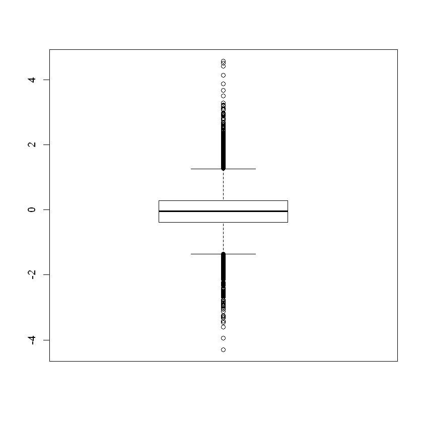

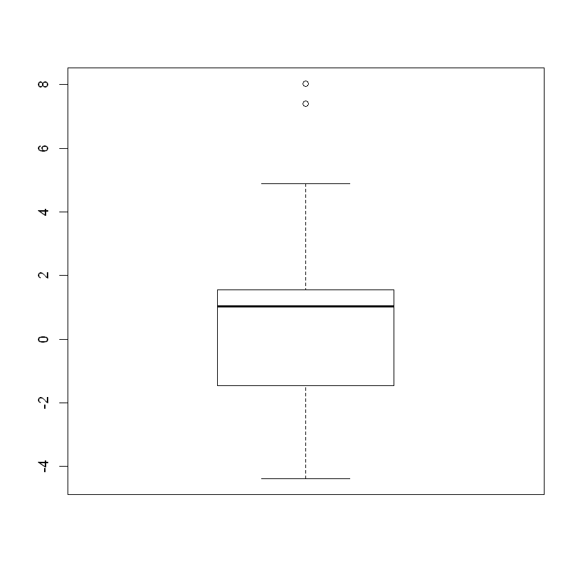

```r
boxplot(geneList)
boxplot(DEG$logFC)
```

```r
#得到排序后的geneList
geneList<-DEG$logFC#赋值
names(geneList)<-DEG$ENTREZID
geneList<-sort(geneList,decreasing = T)#从大到小排序
head(geneList)
```

**247**

8.02863104170142

**7704**

7.40167100084314

**65997**

4.89487840146106

**8404**

4.57496462683689

**5625**

4.53141336224362

**28999**

4.42381460169865

### KEGG pathway analysis

```r
#KEGG
kk.up <- enrichKEGG(gene = gene_up,
                    organism = 'hsa',
                    universe= gene_all,
                    pvalueCutoff = 1,
                    qvalueCutoff =1)
head(kk.up,3)
```

A data.frame: 3 × 9

|  | ID <chr> | Description <chr> | GeneRatio <chr> | BgRatio <chr> | pvalue <dbl> | p.adjust <dbl> | qvalue <dbl> | geneID <chr> | Count <int> |
| --- | --- | --- | --- | --- | --- | --- | --- | --- | --- |
| hsa05165 | hsa05165 | Human papillomavirus infection | 10/75 | 20/277 | 0.02002937 | 0.7811456 | 0.7800914 | 1285/1286/1311/2308/7855/8325/8515/3908/5295/7057 | 10 |
| hsa04512 | hsa04512 | ECM-receptor interaction | 6/75 | 11/277 | 0.04611958 | 0.8993319 | 0.8981182 | 1285/1286/1311/8515/3908/7057 | 6 |
| hsa04151 | hsa04151 | PI3K-Akt signaling pathway | 8/75 | 19/277 | 0.10642149 | 0.9446200 | 0.9433452 | 1285/1286/1311/27006/8515/3908/5295/7057 | 8 |

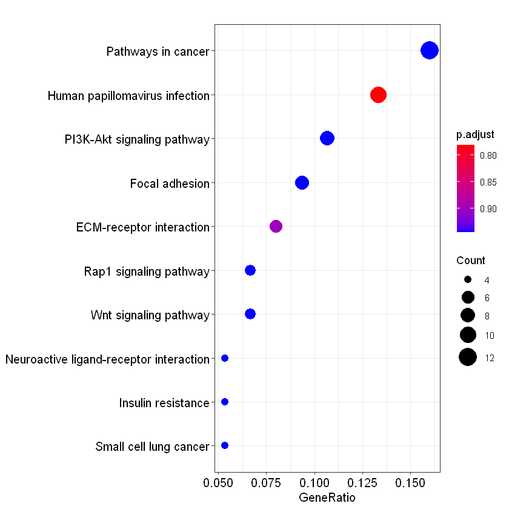

```r
dotplot(kk.up )
```

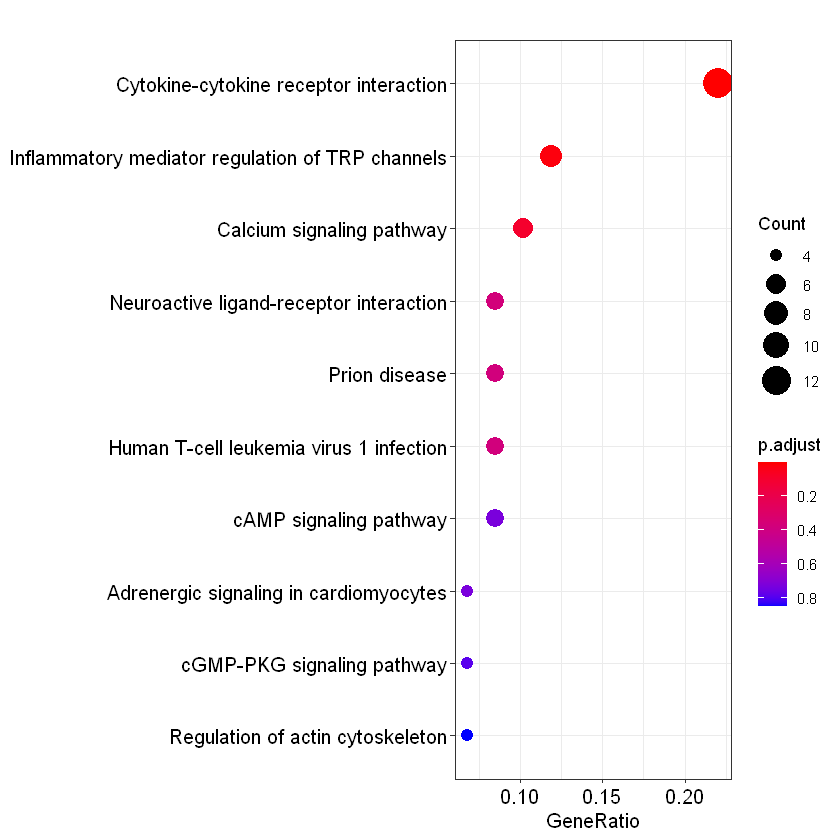

```r
kk.down<- enrichKEGG(gene         = gene_down,
                    organism     = 'hsa',
                    universe     = gene_all,
                    pvalueCutoff = 1,
                    qvalueCutoff =1)
dotplot(kk.down )
```

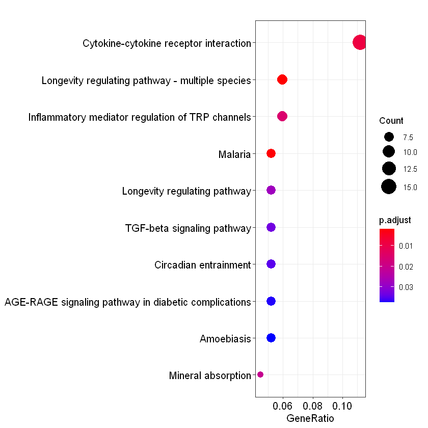

```r
kk.diff<-enrichKEGG(gene=gene_diff,organism = 'hsa',pvalueCutoff = 0.05)
dotplot(kk.diff)
```

```r
kegg_diff_dt <- as.data.frame(kk.diff)
kegg_down_dt <- as.data.frame(kk.down)
kegg_up_dt <- as.data.frame(kk.up)
down_kegg<-kegg_down_dt[kegg_down_dt$pvalue<0.05,]
down_kegg$group=-1
up_kegg<-kegg_up_dt[kegg_up_dt$pvalue<0.05,]
up_kegg$group=1
b<-rbind(down_kegg,up_kegg)
head(b)
```

A data.frame: 6 × 10

|  | ID <chr> | Description <chr> | GeneRatio <chr> | BgRatio <chr> | pvalue <dbl> | p.adjust <dbl> | qvalue <dbl> | geneID <chr> | Count <int> | group <dbl> |
| --- | --- | --- | --- | --- | --- | --- | --- | --- | --- | --- |
| hsa04060 | hsa04060 | Cytokine-cytokine receptor interaction | 13/59 | 22/277 | 5.927126e-05 | 0.002252308 | 0.002121287 | 6387/9518/3592/3557/146433/83729/3976/7042/4982/10673/9966/8744/85480 | 13 | -1 |
| hsa04750 | hsa04750 | Inflammatory mediator regulation of TRP channels | 7/59 | 10/277 | 1.023191e-03 | 0.019440632 | 0.018309736 | 196883/40/623/624/815/8503/5321 | 7 | -1 |
| hsa04020 | hsa04020 | Calcium signaling pathway | 6/59 | 10/277 | 7.656089e-03 | 0.096977122 | 0.091335794 | 196883/623/624/815/2903/5027 | 6 | -1 |
| hsa04080 | hsa04080 | Neuroactive ligand-receptor interaction | 5/59 | 10/277 | 3.919920e-02 | 0.372392408 | 0.350729692 | 623/624/2903/2847/5027 | 5 | -1 |
| hsa05165 | hsa05165 | Human papillomavirus infection | 10/75 | 20/277 | 2.002937e-02 | 0.781145556 | 0.780091378 | 1285/1286/1311/2308/7855/8325/8515/3908/5295/7057 | 10 | 1 |
| hsa04512 | hsa04512 | ECM-receptor interaction | 6/75 | 11/277 | 4.611958e-02 | 0.899331871 | 0.898118198 | 1285/1286/1311/8515/3908/7057 | 6 | 1 |

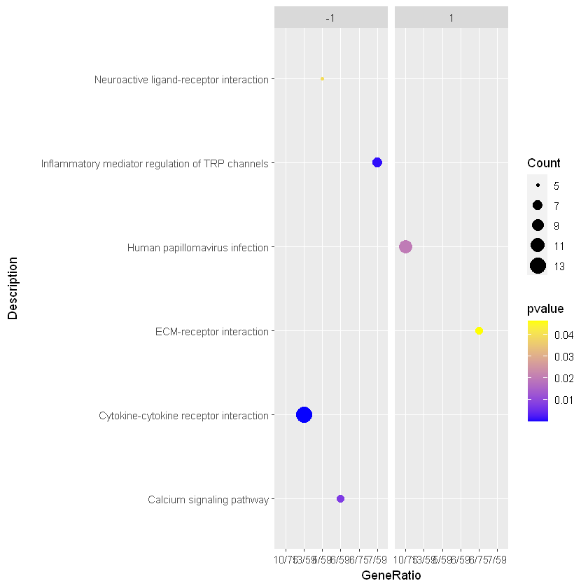

```r
p<-ggplot(b,aes(x=GeneRatio,y=Description))+geom_point(aes(col=pvalue,size=Count))+
  facet_grid(~group)
p+scale_color_gradient2(low="navyblue",mid="blue",high="yellow")
```

A data.frame: 3 × 9

|  | ID <chr> | Description <chr> | GeneRatio <chr> | BgRatio <chr> | pvalue <dbl> | p.adjust <dbl> | qvalue <dbl> | geneID <chr> | Count <int> |
| --- | --- | --- | --- | --- | --- | --- | --- | --- | --- |
| hsa04213 | hsa04213 | Longevity regulating pathway - multiple species | 8/134 | 62/8058 | 7.536378e-06 | 0.001891631 | 0.001578673 | 2308/3306/8660/5295/51422/196883/3310/8503 | 8 |
| hsa05144 | hsa05144 | Malaria | 7/134 | 50/8058 | 1.654599e-05 | 0.002076522 | 0.001732975 | 1311/7057/3039/3040/3592/7042/7412 | 7 |
| hsa04060 | hsa04060 | Cytokine-cytokine receptor interaction | 15/134 | 294/8058 | 1.027727e-04 | 0.008598647 | 0.007176057 | 151449/3625/6387/9518/3592/3557/146433/83729/3976/7042/4982/10673/9966/8744/85480 | 15 |

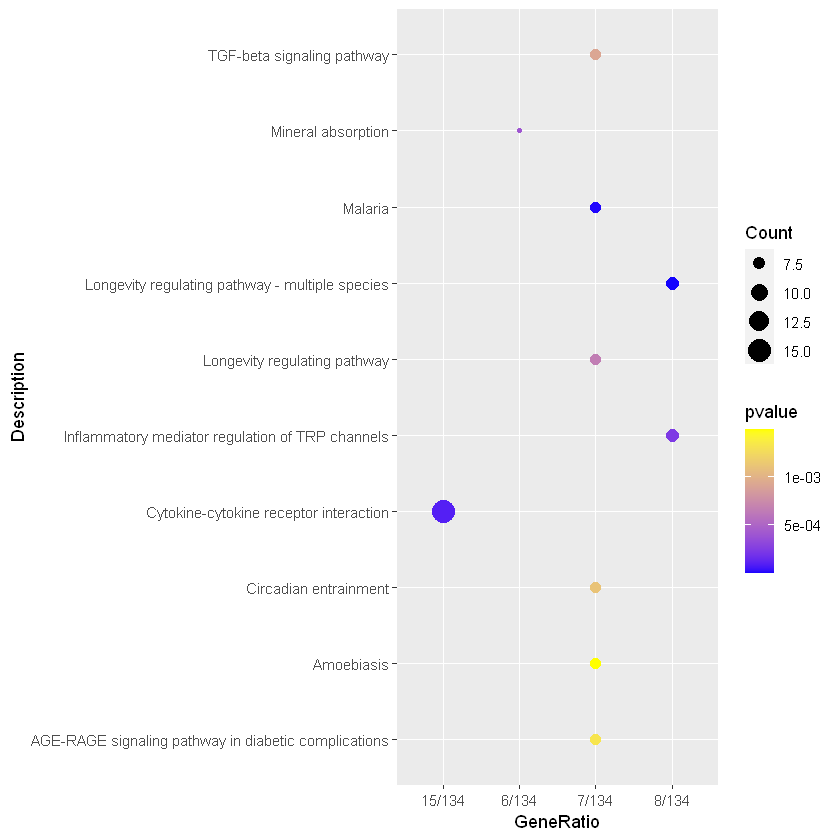

```r
head(kegg_diff_dt,3)
j<-ggplot(kegg_diff_dt,aes(x=GeneRatio,y=Description))+geom_point(aes(col=pvalue,size=Count))
j+scale_color_gradient2(low="navyblue",mid="blue",high="yellow")
```

### GSEA

```r
kk_gse <- gseKEGG(geneList     = geneList,
                    organism     = 'hsa',
                    pvalueCutoff = 1,
                    verbose      = FALSE)
  head(kk_gse)[,1:6]
```

A data.frame: 6 × 6

|  | ID <chr> | Description <chr> | setSize <int> | enrichmentScore <dbl> | NES <dbl> | pvalue <dbl> |
| --- | --- | --- | --- | --- | --- | --- |
| hsa04060 | hsa04060 | Cytokine-cytokine receptor interaction | 22 | -0.4723285 | -2.122202 | 0.002398082 |
| hsa04750 | hsa04750 | Inflammatory mediator regulation of TRP channels | 10 | -0.6112319 | -2.011371 | 0.004618938 |
| hsa04512 | hsa04512 | ECM-receptor interaction | 11 | 0.5139663 | 1.660449 | 0.040636042 |
| hsa04020 | hsa04020 | Calcium signaling pathway | 10 | -0.4466430 | -1.469761 | 0.071593533 |
| hsa05165 | hsa05165 | Human papillomavirus infection | 20 | 0.3666823 | 1.443339 | 0.079861111 |
| hsa04510 | hsa04510 | Focal adhesion | 16 | 0.3521086 | 1.297990 | 0.162544170 |

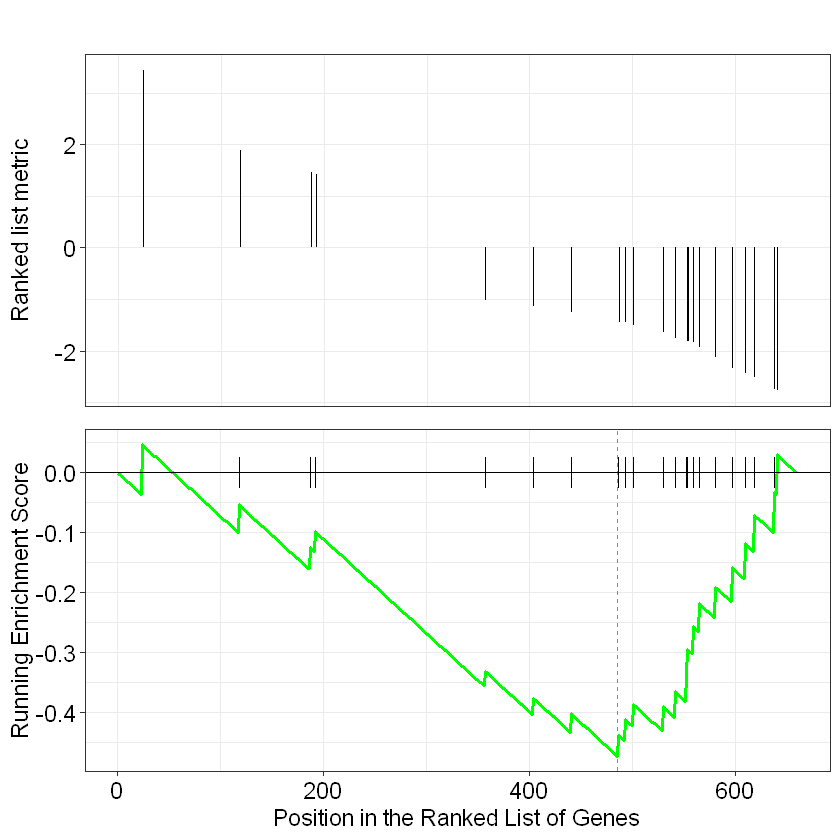

```r
gseaplot(kk_gse, geneSetID = rownames(kk_gse[1,]))
```

```r
down_kegg<-kk_gse[kk_gse$pvalue<0.05 & kk_gse$enrichmentScore < 0,]
down_kegg$group=-1
  up_kegg<-kk_gse[kk_gse$pvalue<0.05 & kk_gse$enrichmentScore > 0,]
up_kegg$group=1
head(up_kegg)
```

A data.frame: 1 × 12

|  | ID <chr> | Description <chr> | setSize <int> | enrichmentScore <dbl> | NES <dbl> | pvalue <dbl> | p.adjust <dbl> | qvalues <dbl> | rank <dbl> | leading_edge <chr> | core_enrichment <chr> | group <dbl> |
| --- | --- | --- | --- | --- | --- | --- | --- | --- | --- | --- | --- | --- |
| hsa04512 | hsa04512 | ECM-receptor interaction | 11 | 0.5139663 | 1.660449 | 0.04063604 | 0.5282686 | 0.5132974 | 248 | tags=82%, list=38%, signal=52% | 8515/1285/3908/7057/1286/1311/3161/1282/8516 | 1 |

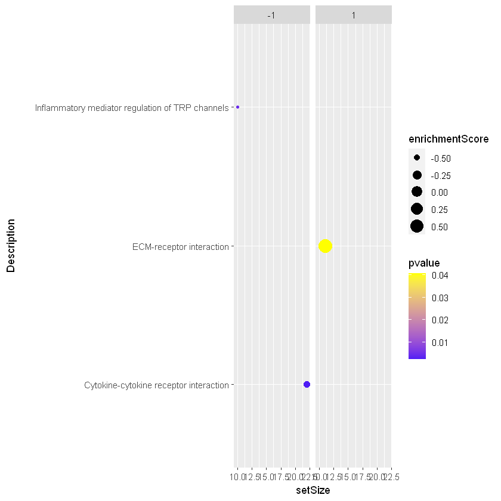

```r
h<-rbind(down_kegg,up_kegg)
m<-ggplot(h,aes(x=setSize,y=Description))+geom_point(aes(col=pvalue,size=enrichmentScore))+ facet_grid(~group)
m+scale_color_gradient2(low="navyblue",mid="blue",high="yellow")
```

详细可参考以下帖子 https://www.jianshu.com/p/5ca79763e07e http://www.lab-bj.com/index.php?r=service/detail&serviceid=11352